# PCA

Here we shall be applying PCA (Principal Component Analysis) to a data set, and stepwise show how the PCA is calculated in general, using inbuilt functions prcomp, princomp.

Arguements taken by function prcomp:

formula: formula with no respomse variable refering only to numeric value.  
data: an optional data frame containing the variables from the formula

the default is:

x: a numeric matrix or data frame  
scale: a logical value indicating whether the variables should be scaled to have unit variance before the analysis takes place

Arguements takn by the function princomp:

x: a numeric matrix or data frame  
cor: a logical value. If TRUE, the data will be centered and scaled before the analysis  
scores: a logical value. If TRUE, the coordinates on each principal component are calculated

The elements of the outputs returned by the functions prcomp() and princomp() includes :

```r
read.csv("required.csv", header = T)
```

| prcomp..name | princomp...name | Description. |
| --- | --- | --- |
| sdev | sdev | the standard deviation of the principle components |
| rotation | loadings | the matrix of variable loadings (columns are eigenvectors) |
| centre | centre | the variable means (means that were substracted)\n |
| scale | scale | the variable standard deviations (the scaling applied to each variable )\n |
| x | scores | The coordinates of the individuals (observations) on the principal components. |

Now we shall work with two different datasets.

```r
data=read.table("pcadatawin.txt", header = T) # this is a imported data set.
head(data)
```

|  | x | y | z |
| --- | --- | --- | --- |
| 1 | -0.59273943 | -0.3969902 | -0.211460711 |
| 2 | 1.33928981 | 0.3481822 | 0.805695615 |
| 3 | -0.16905177 | 0.2907295 | 0.001100075 |
| 4 | 1.31753918 | 1.5245951 | 0.806680544 |
| 5 | -0.08794033 | -0.7123229 | -0.178526119 |
| 6 | -0.37700055 | -1.0895518 | -0.246642602 |

The dimension of the data set are as follows.

```r
dim(data)
```

```
## [1] 100   3
```

Let us try to visualize the data. To obtain a 3D visualization we shall first  
1. Install a package called “devtools” 2. Then we use devtools::install_github(“AckerDWM/gg3D”) which downloads the gg3D directly from github repository AckerDWM.

This package is useful in giving 3D plots showing 3 axes. The following example gives and empty plot.

```r
library("gg3D")
```

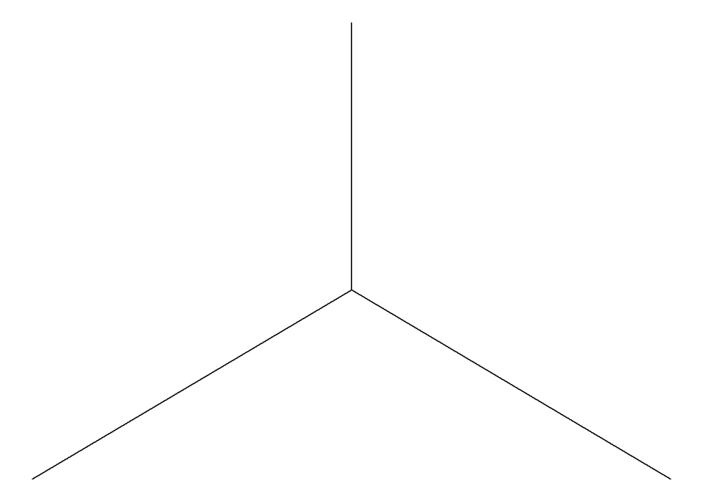

```r
## An empty plot with 3 axes
qplot(x=0, y=0, z=0, geom="blank") +
  theme_void() +
  axes_3D()
```

This will give the necessary 3D representation the data points for iris dataset, and the imported data set respectively.

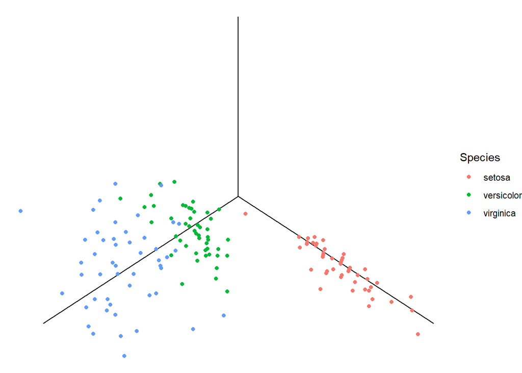

```r
data(iris)
ggplot(iris, aes(x=Petal.Width, y=Sepal.Width, z=Petal.Length, color=Species)) +
  theme_void() +
  axes_3D() +
  stat_3D()
```

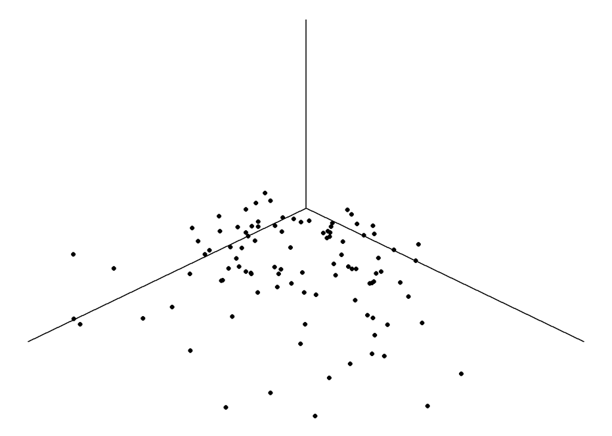

```r
ggplot(data, aes(x=x, y=y, z=z)) +
  theme_void() +
  axes_3D() +
  stat_3D()
```

The last three plots give a visualization of the data, The first plot shows that the data is spread in the x-y plane and partly in the z axis, the second plot for the other set of data shows that the points are spread mostly in the x-y plane. This gives a intuition about what can be the Principal components. Next we shall apply “prcomp()” to find out the PCs and the the scree plot for both the set of datas.

```r
library(factoextra)
pc=prcomp(data, scale= FALSE)
pc
```

```
## Standard deviations (1, .., p=3):
## [1] 1.0318927 0.4813952 0.1087654
##
## Rotation (n x k) = (3 x 3):
##         PC1        PC2         PC3
## x 0.6691776  0.4797023  0.56752718
## y 0.5765168 -0.8170139  0.01080358
## z 0.4688601  0.3199594 -0.82328378
```

```r
pc1=princomp(data, scores = TRUE) #using princomp
pc1
```

```
## Call:
## princomp(x = data, scores = TRUE)
##
## Standard deviations:
##    Comp.1    Comp.2    Comp.3
## 1.0267203 0.4789821 0.1082202
##
##  3  variables and  100 observations.
```

```r
names(pc1)
```

```
## [1] "sdev"     "loadings" "center"   "scale"    "n.obs"    "scores"   "call"
```

```r
names(pc)
```

```
## [1] "sdev"     "rotation" "center"   "scale"    "x"
```

We see that both prcomp and princomp gives nearly the same values. x in prcomp are the scores in primcomp.

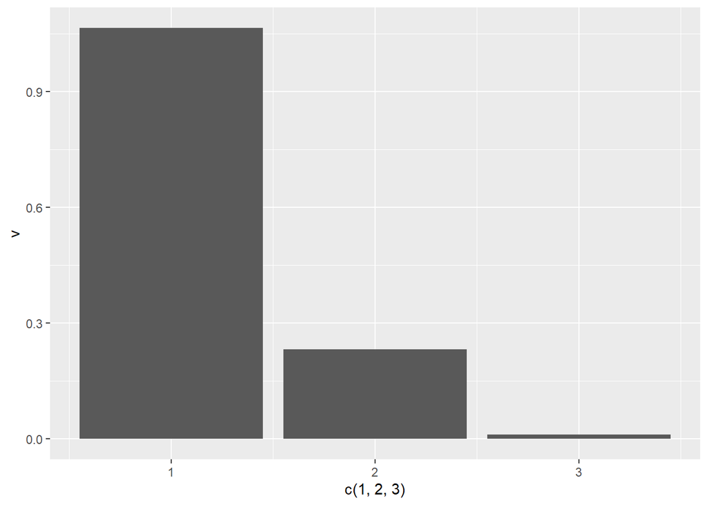

```r
pc_plotdata=data.frame(v=pc$sdev)^2
ggplot(data=pc_plotdata)+
  geom_col(mapping = aes(x=c(1,2,3), y=v)) #same as bar taking stat= "identity by default
```

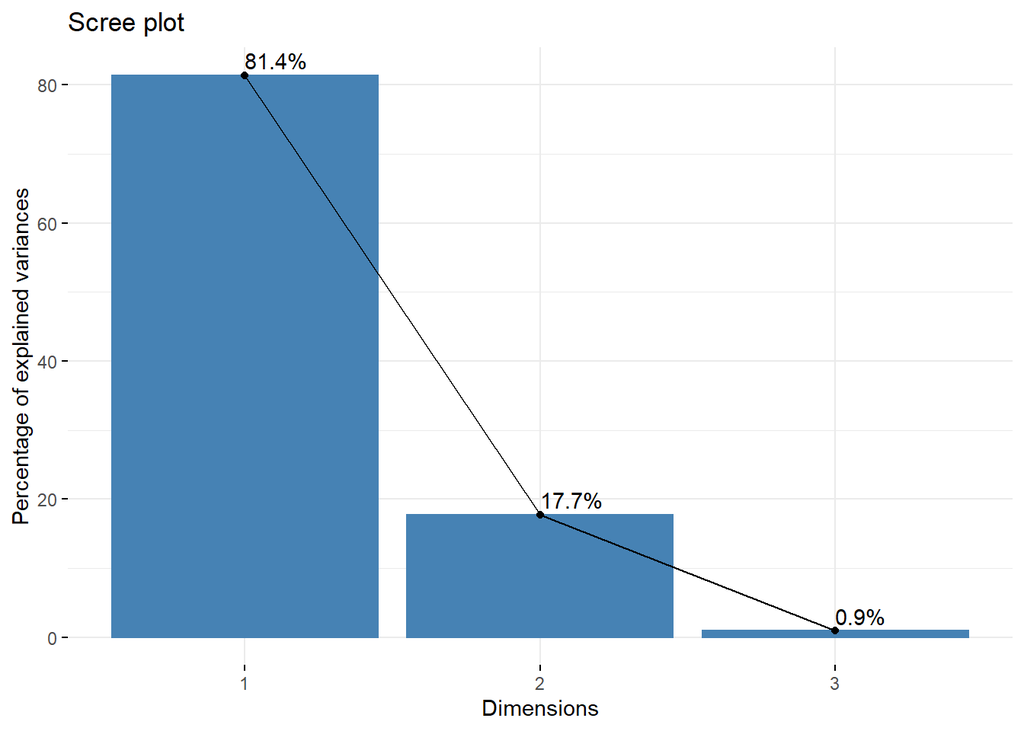

```r
fviz_eig(pc, addlabels = TRUE)
```

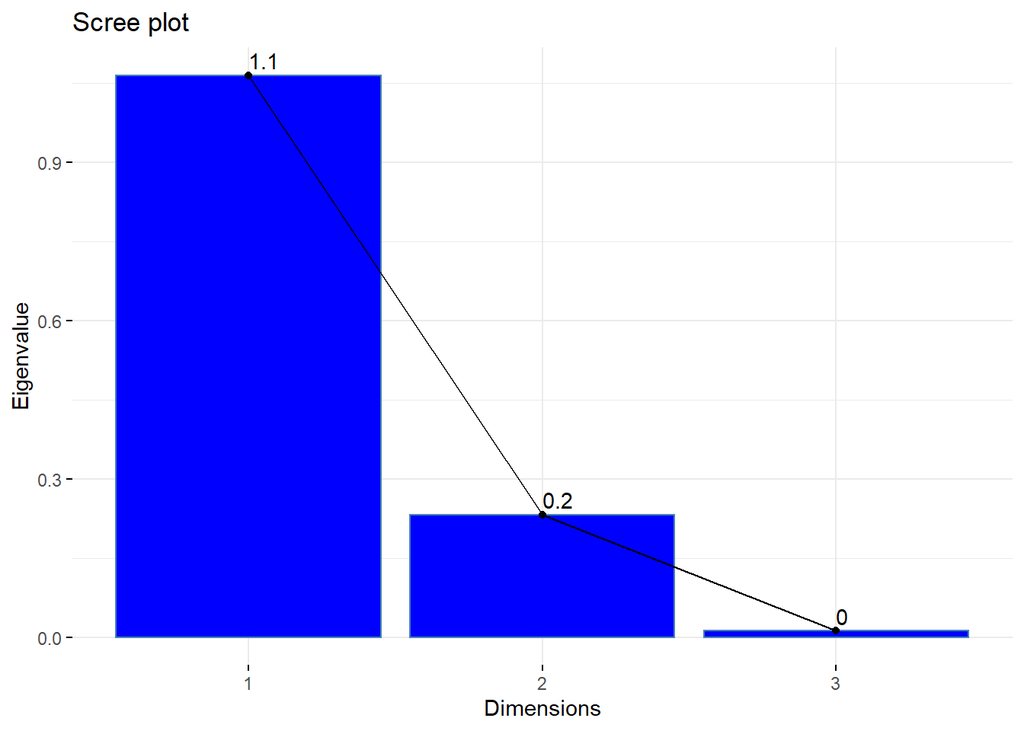

```r
fviz_screeplot(pc, choice="eigenvalue",
               barfill= "blue", addlabels= TRUE)
```

Now working with IRIS dataset.

```r
iris1=iris[-5]
pc=prcomp(iris1, scale= FALSE)
pc
```

```
## Standard deviations (1, .., p=4):
## [1] 2.0562689 0.4926162 0.2796596 0.1543862
##
## Rotation (n x k) = (4 x 4):
##                      PC1         PC2         PC3        PC4
## Sepal.Length  0.36138659 -0.65658877  0.58202985  0.3154872
## Sepal.Width  -0.08452251 -0.73016143 -0.59791083 -0.3197231
## Petal.Length  0.85667061  0.17337266 -0.07623608 -0.4798390
## Petal.Width   0.35828920  0.07548102 -0.54583143  0.7536574
```

```r
pc1=princomp(iris1, scores = TRUE) #using princomp
pc1
```

```
## Call:
## princomp(x = iris1, scores = TRUE)
##
## Standard deviations:
##    Comp.1    Comp.2    Comp.3    Comp.4
## 2.0494032 0.4909714 0.2787259 0.1538707
##
##  4  variables and  150 observations.
```

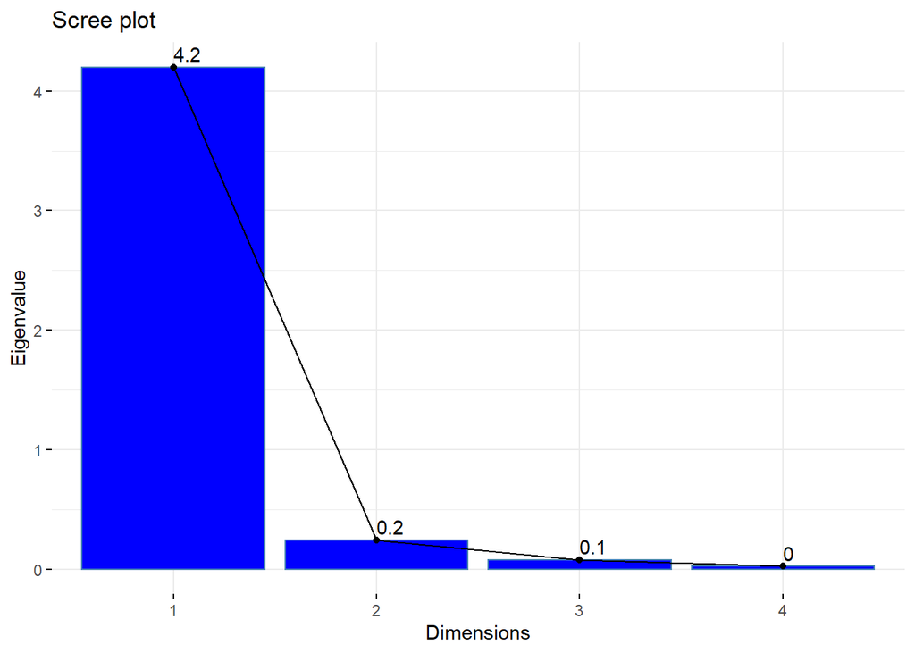

```r
fviz_screeplot(pc1, choice="eigenvalue",
               barfill= "blue", addlabels= TRUE)
```

# PCA

Here we shall be applying PCA (Principal Component Analysis) to a data set, and stepwise show how the PCA is calculated in general, using inbuilt functions prcomp, princomp.

Arguements taken by function prcomp:

formula: formula with no respomse variable refering only to numeric value.  
data: an optional data frame containing the variables from the formula

the default is:

x: a numeric matrix or data frame  
scale: a logical value indicating whether the variables should be scaled to have unit variance before the analysis takes place

Arguements takn by the function princomp:

x: a numeric matrix or data frame  
cor: a logical value. If TRUE, the data will be centered and scaled before the analysis  
scores: a logical value. If TRUE, the coordinates on each principal component are calculated

The elements of the outputs returned by the functions prcomp() and princomp() includes :

```r
read.csv("required.csv", header = T)
```

| prcomp..name | princomp...name | Description. |
| --- | --- | --- |
| sdev | sdev | the standard deviation of the principle components |
| rotation | loadings | the matrix of variable loadings (columns are eigenvectors) |
| centre | centre | the variable means (means that were substracted)\n |
| scale | scale | the variable standard deviations (the scaling applied to each variable )\n |
| x | scores | The coordinates of the individuals (observations) on the principal components. |

Now we shall work with two different datasets.

```r
data=read.table("pcadatawin.txt", header = T) # this is a imported data set.
head(data)
```

|  | x | y | z |
| --- | --- | --- | --- |
| 1 | -0.59273943 | -0.3969902 | -0.211460711 |
| 2 | 1.33928981 | 0.3481822 | 0.805695615 |
| 3 | -0.16905177 | 0.2907295 | 0.001100075 |
| 4 | 1.31753918 | 1.5245951 | 0.806680544 |
| 5 | -0.08794033 | -0.7123229 | -0.178526119 |
| 6 | -0.37700055 | -1.0895518 | -0.246642602 |

The dimension of the data set are as follows.

```r
dim(data)
```

```
## [1] 100   3
```

Let us try to visualize the data. To obtain a 3D visualization we shall first  
1. Install a package called “devtools” 2. Then we use devtools::install_github(“AckerDWM/gg3D”) which downloads the gg3D directly from github repository AckerDWM.

This package is useful in giving 3D plots showing 3 axes. The following example gives and empty plot.

```r
library("gg3D")
```

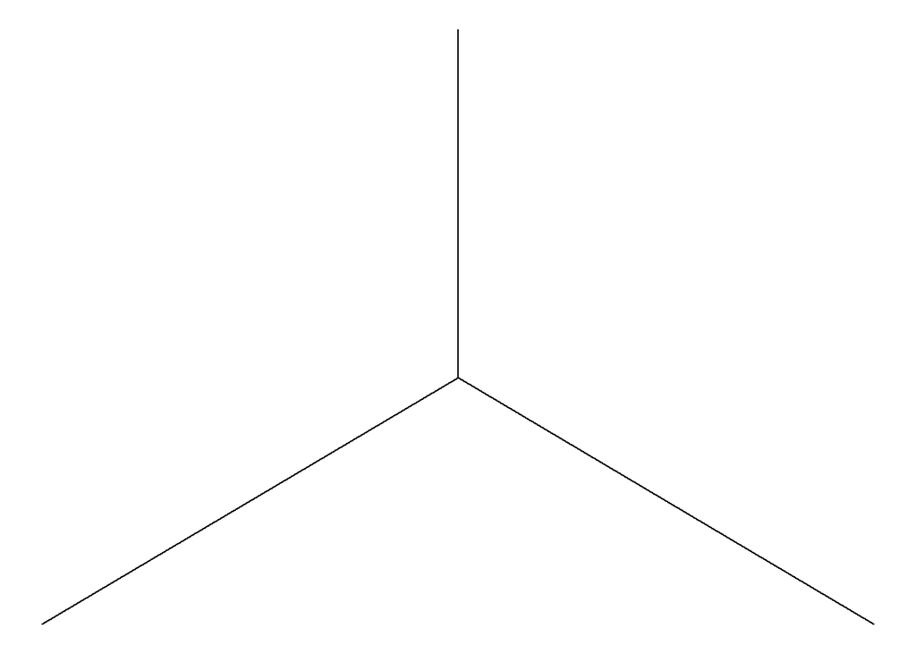

```r
## An empty plot with 3 axes
qplot(x=0, y=0, z=0, geom="blank") +
  theme_void() +
  axes_3D()
```

This will give the necessary 3D representation the data points for iris dataset, and the imported data set respectively.

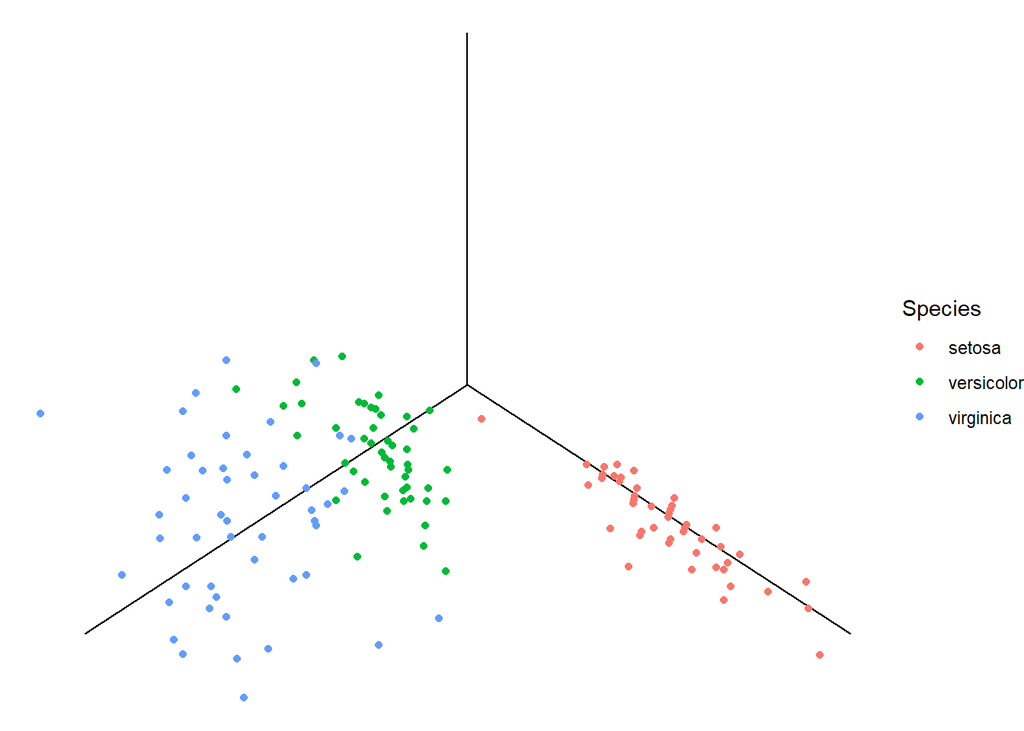

```r
data(iris)
ggplot(iris, aes(x=Petal.Width, y=Sepal.Width, z=Petal.Length, color=Species)) +
  theme_void() +
  axes_3D() +
  stat_3D()
```

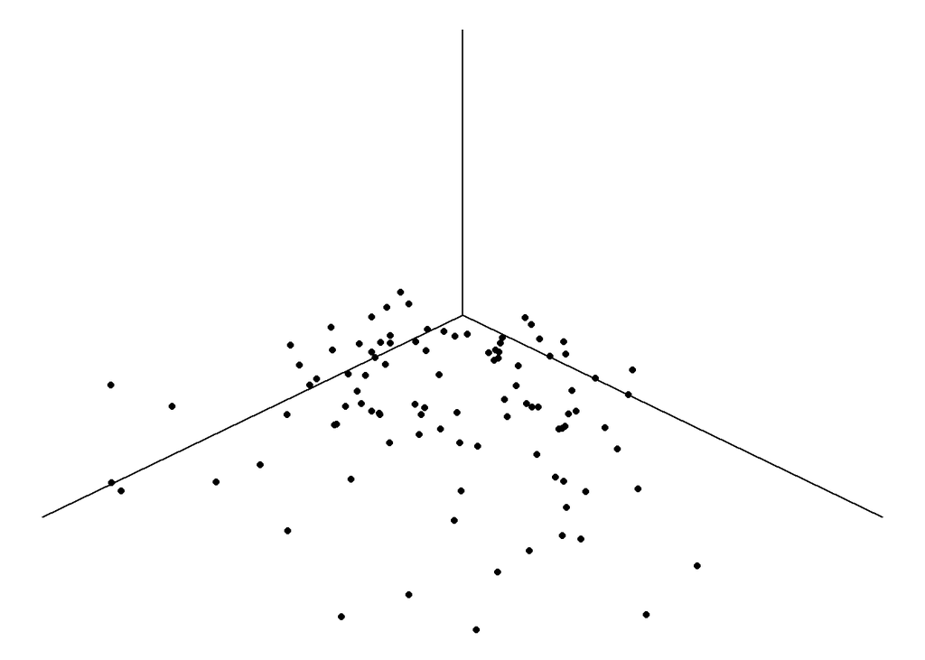

```r
ggplot(data, aes(x=x, y=y, z=z)) +
  theme_void() +
  axes_3D() +
  stat_3D()
```

The last three plots give a visualization of the data, The first plot shows that the data is spread in the x-y plane and partly in the z axis, the second plot for the other set of data shows that the points are spread mostly in the x-y plane. This gives a intuition about what can be the Principal components. Next we shall apply “prcomp()” to find out the PCs and the the scree plot for both the set of datas.

```r
library(factoextra)
pc=prcomp(data, scale= FALSE)
pc
```

```
## Standard deviations (1, .., p=3):
## [1] 1.0318927 0.4813952 0.1087654
##
## Rotation (n x k) = (3 x 3):
##         PC1        PC2         PC3
## x 0.6691776  0.4797023  0.56752718
## y 0.5765168 -0.8170139  0.01080358
## z 0.4688601  0.3199594 -0.82328378
```

```r
pc1=princomp(data, scores = TRUE) #using princomp
pc1
```

```
## Call:
## princomp(x = data, scores = TRUE)
##
## Standard deviations:
##    Comp.1    Comp.2    Comp.3
## 1.0267203 0.4789821 0.1082202
##
##  3  variables and  100 observations.
```

```r
names(pc1)
```

```
## [1] "sdev"     "loadings" "center"   "scale"    "n.obs"    "scores"   "call"
```

```r
names(pc)
```

```
## [1] "sdev"     "rotation" "center"   "scale"    "x"
```

We see that both prcomp and princomp gives nearly the same values. x in prcomp are the scores in primcomp.

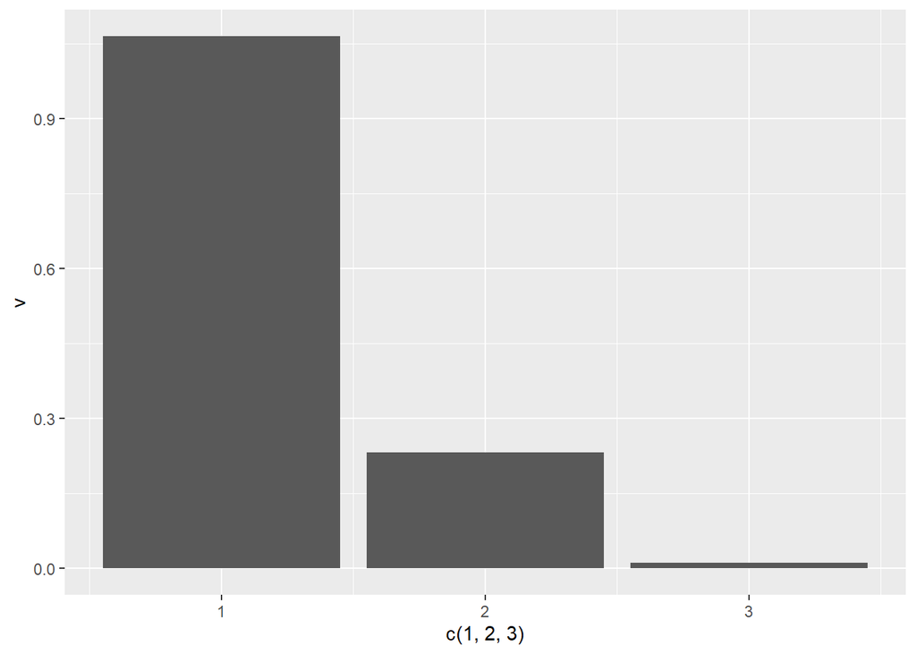

```r
pc_plotdata=data.frame(v=pc$sdev)^2
ggplot(data=pc_plotdata)+
  geom_col(mapping = aes(x=c(1,2,3), y=v)) #same as bar taking stat= "identity by default
```

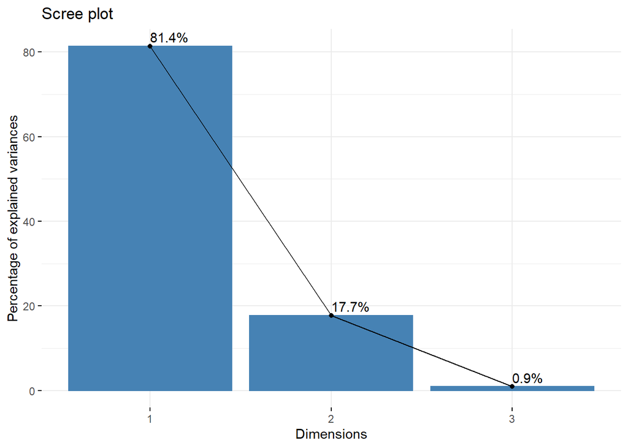

```r
fviz_eig(pc, addlabels = TRUE)
```

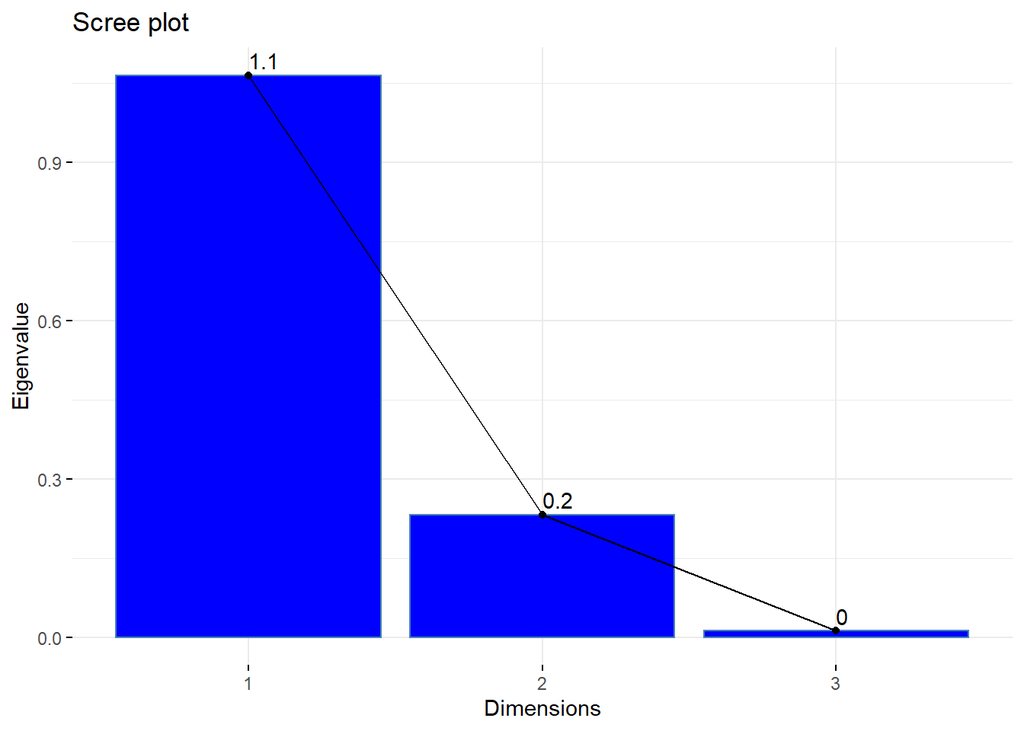

```r
fviz_screeplot(pc, choice="eigenvalue",
               barfill= "blue", addlabels= TRUE)
```

Now working with IRIS dataset.

```r
iris1=iris[-5]
pc=prcomp(iris1, scale= FALSE)
pc
```

```
## Standard deviations (1, .., p=4):
## [1] 2.0562689 0.4926162 0.2796596 0.1543862
##
## Rotation (n x k) = (4 x 4):
##                      PC1         PC2         PC3        PC4
## Sepal.Length  0.36138659 -0.65658877  0.58202985  0.3154872
## Sepal.Width  -0.08452251 -0.73016143 -0.59791083 -0.3197231
## Petal.Length  0.85667061  0.17337266 -0.07623608 -0.4798390
## Petal.Width   0.35828920  0.07548102 -0.54583143  0.7536574
```

```r
pc1=princomp(iris1, scores = TRUE) #using princomp
pc1
```

```
## Call:
## princomp(x = iris1, scores = TRUE)
##
## Standard deviations:
##    Comp.1    Comp.2    Comp.3    Comp.4
## 2.0494032 0.4909714 0.2787259 0.1538707
##
##  4  variables and  150 observations.
```

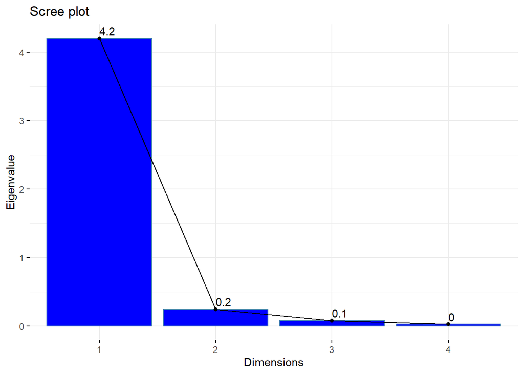

```r
fviz_screeplot(pc1, choice="eigenvalue",
               barfill= "blue", addlabels= TRUE)
```